# Using the capstoneR Package

Susmit Sarker

16 June, 2018

capstoneR is a package developed as the capstone project for the Advanced R Programming specialization on Coursera. This vignette gives a brief overview of the capstoneR R package created for the purpose of visualizing NOAA earthquake data. It processes data from [NOAA database](https://www.ngdc.noaa.gov/nndc/struts/form?t=101650&s=1&d=1) and visualizes them using `ggplot2` and `leaflet` packages.

## Package functions

Following are exported functions available to users:

- `eq_clean_data()`
- `geom_timeline()`
- `geom_timeline_label()`
- `eq_create_label()`
- `eq_map()`

This document serves as an introduction to the package and demonstrates how to use each of the individual features.

## Clean the Data

Some cleaning is required to get the data ready to work nicely with the visualization functions provided below. The easist thing to do is simply to load the clean dataset included with this package using the `data()` function:

```r
data('clean_NOAA')
```

```r
clean_NOAA <- readr::read_delim('signif.txt',delim = '\t') %>%
    eq_clean_data()
```

## Timeline Visualization

A timeline is a great way to see when significant earthquakes have ocurred. This package includes a custom `geom` and `stat` to make creating just such a plot easier with the widely-used `ggplot2` package. The basic `geom_timeline()` geom requires clean data from the previous paragraph. The `geom_timeline_label()` function requires additional `label` aesthetic for labeling.

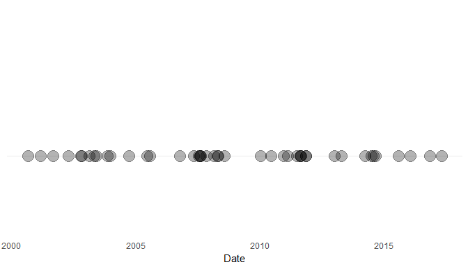

```r
filter(clean_NOAA, COUNTRY == "USA") %>% ggplot(aes(x = DATE)) +
    geom_timeline(x_min = ymd("2000-01-01"), x_max = ymd("2017-07-01")) +
    theme_minimal() + theme(panel.grid.major.x = element_blank()) +
    theme(axis.text.y  = element_blank()) +
    theme(panel.grid.minor.x = element_blank()) +
    scale_y_continuous(breaks = 1, limits = c(0.5, 2)) +
    labs(x = "Date")
```

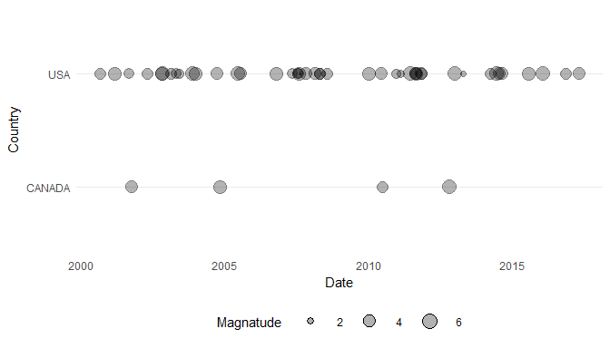

```r
filter(clean_NOAA, COUNTRY == "USA" | COUNTRY == "CANADA") %>%
    ggplot(aes(x = DATE, y = COUNTRY, size = EQ_PRIMARY)) +
    geom_timeline(x_min = ymd("2000-01-01"), x_max = ymd("2017-07-01")) +
    theme_minimal() + theme(panel.grid.major.x = element_blank()) +
    theme(panel.grid.minor.x = element_blank()) + theme(legend.position = "bottom") +
    theme(legend.key.size = unit(0.078, 'npc')) +
    labs(x = "Date", y = "Country", size = "Magnatude")
```

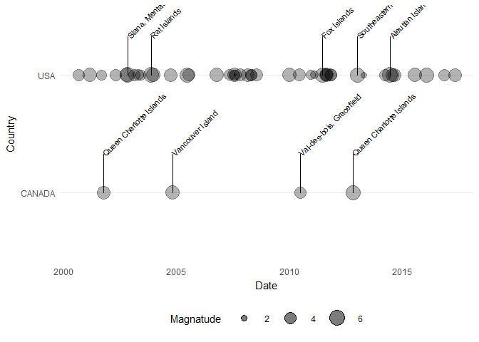

```r
xmin <- ymd("2000-01-01")
xmax <- ymd("2017-07-01")
filter(clean_NOAA, COUNTRY == "CANADA" | COUNTRY == "USA") %>%
    ggplot(aes(x = DATE, y = COUNTRY, size = EQ_PRIMARY)) +
    geom_timeline(x_min = xmin, x_max = xmax) +
    geom_timeline_label(aes(label = LOCATION_NAME, magnatude = EQ_PRIMARY),
                        x_min = xmin, x_max = xmax, top_x_mag = 5) +
    theme_minimal() + theme(panel.grid.major.x = element_blank()) +
    theme(panel.grid.minor.x = element_blank()) + theme(legend.position = "bottom") +
    theme(legend.key.size = unit(0.078, 'npc')) +
    labs(x = "Date", y = "Country", size = "Magnatude")
```

## Visualize earthquakes on map

The package utilized `leaflet` functions to visualize earthquakes on a map using `eq_map()` function. The map is automatically trimmed to display the input data frame. Optional annotations can be created using `eq_create_label()` function. The result is an interactive map where user can click on individual points to get details:

```r
map <- clean_NOAA %>%
          dplyr::filter(COUNTRY == "MEXICO" & lubridate::year(DATE) >= 2000) %>%
          dplyr::mutate(popup_text = eq_create_label(.)) %>%
          eq_map(annot_col = "popup_text")
map
```

[interactive chart not shown]